# chapter14-xinqiancai

## 6. Create a new variable in the data called `ipw` with the inverse probability weight, and then estimate the treatment effect using those weights in a linear regression (keeping in mind the standard errors won’t be quite right).## Note that the same tools you used to trim `propensity` conditional on its value can also be used to calculate `ipw` in one way for treated observations and in another way for untreated observations.

```r
# creating ipw
ipw<-get_w_from_ps(ps=md5$propensity,treat = md5$treat, estimand = "ATE")
summary(ipw)
```

```
##    Min. 1st Qu.  Median    Mean 3rd Qu.    Max.
##   1.242   1.585   1.802   1.999   2.407   4.203
```

```r
md6<-md5|>
  mutate(ipw=ipw)

# estimate treatment effect
matchdiff6<-lm(re78~treat, data = md6, weights = ipw)
tidy(matchdiff6, conf.int=TRUE)
```

```
## # A tibble: 2 x 7
##   term        estimate std.error statistic  p.value conf.low conf.high
##   <chr>          <dbl>     <dbl>     <dbl>    <dbl>    <dbl>     <dbl>
## 1 (Intercept)    4550.      454.     10.0  2.04e-21    3657.     5443.
## 2 treat          1641.      643.      2.55 1.11e- 2     377.     2906.
```

```r
summary(matchdiff6)
```

```
##
## Call:
## lm(formula = re78 ~ treat, data = md6, weights = ipw)
##
## Weighted Residuals:
##    Min     1Q Median     3Q    Max
## -10570  -5849  -2362   4126  88724
##
## Coefficients:
##             Estimate Std. Error t value Pr(>|t|)
## (Intercept)   4549.8      454.3  10.015   <2e-16 ***
## treat         1641.3      643.3   2.551   0.0111 *
## ---
## Signif. codes:  0 '***' 0.001 '**' 0.01 '*' 0.05 '.' 0.1 ' ' 1
##
## Residual standard error: 9593 on 443 degrees of freedom
## Multiple R-squared:  0.01448,    Adjusted R-squared:  0.01226
## F-statistic:  6.51 on 1 and 443 DF,  p-value: 0.01106
```

```r
# The average treatment effect is that taking the job-training program is associated with the 1641 dollars increase in the real earnings in 1978.
```

## 7. Make a common support graph, overlaying the density of the `propensity` variable for treated observations on top of the density of the `propensity` variable for untreated observations. You may want to refer to [this guide](https://lost-stats.github.io/Presentation/Figures/density_plots.html) if you are not familiar with your language’s graphing capabilities. Write a line commenting on how the common support looks.

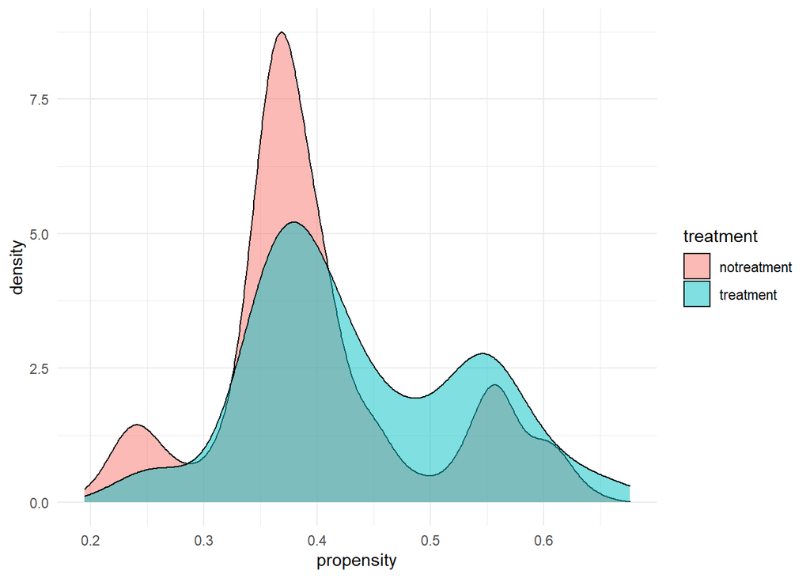

```r
md7<-md6|>
  select(treat,propensity)|>
  mutate(treatment=case_when(treat==1~'treatment',treat==0~'notreatment'))
ggplot(md7, aes(x = propensity, fill = treatment)) + geom_density(alpha = 0.5)
```

```r
# Based on the graph, the assumption of common support of the propensity variable is generally good.
```

## 8. Use the prepackaged command for inverse probability weighting used in the chapter for your language to estimate the treatment effect. Don’t apply a trim (as previously established, for this particular problem it doesn’t do much).

```r
# ps
weight8<-weightit(treat~age+educ+black+hisp+marr+nodegree+re74+re75, data = nsw, method = "ps", estimand = "ATT")


summary(weight8$ps)
```

```
##    Min. 1st Qu.  Median    Mean 3rd Qu.    Max.
##  0.1948  0.3593  0.3914  0.4157  0.4755  0.6756
```

```r
#ipw
md8<-nsw|>
  mutate(ipw=case_when(
    treat==1~1/weight8$ps,
    treat==0~1/(1-weight8$ps)
  ))

## estimate the treatment effect
matchdiff8<-lm(re78~treat, data = md8, weights = ipw)
summary(matchdiff8)
```

```
##
## Call:
## lm(formula = re78 ~ treat, data = md8, weights = ipw)
##
## Weighted Residuals:
##    Min     1Q Median     3Q    Max
## -10570  -5849  -2362   4126  88724
##
## Coefficients:
##             Estimate Std. Error t value Pr(>|t|)
## (Intercept)   4549.8      454.3  10.015   <2e-16 ***
## treat         1641.3      643.3   2.551   0.0111 *
## ---
## Signif. codes:  0 '***' 0.001 '**' 0.01 '*' 0.05 '.' 0.1 ' ' 1
##
## Residual standard error: 9593 on 443 degrees of freedom
## Multiple R-squared:  0.01448,    Adjusted R-squared:  0.01226
## F-statistic:  6.51 on 1 and 443 DF,  p-value: 0.01106
```

```r
msummary(matchdiff8)
```

[output not shown]

```r
# The treatment effect is that taking training program is associated with about 1641 dollars increase in real earnings in 1978.
```